# Clustering

## Instalación

```r
install.packages("tidyverse")   #Utilizada para la manipulación eficiente de datos y visualización.
```

[output not shown]

```r
install.packages("visdat")      #Empleada para la búsqueda de valores nulos en los conjuntos de datos.
```

[output not shown]

```r
install.packages("ggplot2")     #Herramienta clave para la creación de visualizaciones atractivas y efectivas.
```

[output not shown]

```r
install.packages("corrplot")    #Utilizada para analizar y visualizar la correlación entre variables.
```

[output not shown]

```r
install.packages("NbClust")     #Biblioteca para realizar análisis de clustering.
```

[output not shown]

```r
install.packages("factoextra")  #Biblioteca para realizar análisis de clustering.
```

[output not shown]

```r
install.packages("ape")         #Utilizada para la representación gráfica de dendrogramas en análisis jerárquicos.
```

[output not shown]

```r
install.packages("clValid")     #Herramienta crucial para la comparación y validación de algoritmos en el análisis de clustering.
```

[output not shown]

## Importación

```r
suppressPackageStartupMessages(library(dplyr))
library(tidyverse)
```

```r
library(visdat)
library(ggplot2)
library(corrplot)
library(NbClust)
library(factoextra)
library(ape)
library(clValid)
```

## Introducción

En el presente notebook, se tiene como objetivo examinar los patrones existentes en el dataset de ventas de supermercados. La meta consiste en formar grupos con ejemplos más afines y analizar su comportamiento. Con este fin, se implementarán los algoritmos de k-means y clustering jerárquico.

```r
#Leer dataset
sales_df <- read.table("./supermarket_db.csv", na.strings="", header=TRUE, sep=",", dec=".")
dim(sales_df)
```

```
## [1] 1000   17
```

```r
head(sales_df)
```

|  | Invoice.ID | Branch | City | Customer.type | Gender | Product.line | Unit.price | Quantity | Tax.5. | Total | Date | Time | Payment | cogs | gross.margin.percentage | gross.income | Rating |
| --- | --- | --- | --- | --- | --- | --- | --- | --- | --- | --- | --- | --- | --- | --- | --- | --- | --- |
| 1 | 750-67-8428 | A | Yangon | Member | Female | Health and beauty | 74.69 | 7 | 26.1415 | 548.9715 | 1/5/2019 | 13:08 | Ewallet | 522.83 | 4.761905 | 26.1415 | 9.1 |
| 2 | 226-31-3081 | C | Naypyitaw | Normal | Female | Electronic accessories | 15.28 | 5 | 3.8200 | 80.2200 | 3/8/2019 | 10:29 | Cash | 76.40 | 4.761905 | 3.8200 | 9.6 |
| 3 | 631-41-3108 | A | Yangon | Normal | Male | Home and lifestyle | 46.33 | 7 | 16.2155 | 340.5255 | 3/3/2019 | 13:23 | Credit card | 324.31 | 4.761905 | 16.2155 | 7.4 |
| 4 | 123-19-1176 | A | Yangon | Member | Male | Health and beauty | 58.22 | 8 | 23.2880 | 489.0480 | 1/27/2019 | 20:33 | Ewallet | 465.76 | 4.761905 | 23.2880 | 8.4 |
| 5 | 373-73-7910 | A | Yangon | Normal | Male | Sports and travel | 86.31 | 7 | 30.2085 | 634.3785 | 2/8/2019 | 10:37 | Ewallet | 604.17 | 4.761905 | 30.2085 | 5.3 |
| 6 | 699-14-3026 | C | Naypyitaw | Normal | Male | Electronic accessories | 85.39 | 7 | 29.8865 | 627.6165 | 3/25/2019 | 18:30 | Ewallet | 597.73 | 4.761905 | 29.8865 | 4.1 |

```r
str(sales_df)
```

```
## 'data.frame':    1000 obs. of  17 variables:
##  $ Invoice.ID             : chr  "750-67-8428" "226-31-3081" "631-41-3108" "123-19-1176" ...
##  $ Branch                 : chr  "A" "C" "A" "A" ...
##  $ City                   : chr  "Yangon" "Naypyitaw" "Yangon" "Yangon" ...
##  $ Customer.type          : chr  "Member" "Normal" "Normal" "Member" ...
##  $ Gender                 : chr  "Female" "Female" "Male" "Male" ...
##  $ Product.line           : chr  "Health and beauty" "Electronic accessories" "Home and lifestyle" "Health and beauty" ...
##  $ Unit.price             : num  74.7 15.3 46.3 58.2 86.3 ...
##  $ Quantity               : int  7 5 7 8 7 7 6 10 2 3 ...
##  $ Tax.5.                 : num  26.14 3.82 16.22 23.29 30.21 ...
##  $ Total                  : num  549 80.2 340.5 489 634.4 ...
##  $ Date                   : chr  "1/5/2019" "3/8/2019" "3/3/2019" "1/27/2019" ...
##  $ Time                   : chr  "13:08" "10:29" "13:23" "20:33" ...
##  $ Payment                : chr  "Ewallet" "Cash" "Credit card" "Ewallet" ...
##  $ cogs                   : num  522.8 76.4 324.3 465.8 604.2 ...
##  $ gross.margin.percentage: num  4.76 4.76 4.76 4.76 4.76 ...
##  $ gross.income           : num  26.14 3.82 16.22 23.29 30.21 ...
##  $ Rating                 : num  9.1 9.6 7.4 8.4 5.3 4.1 5.8 8 7.2 5.9 ...
```

## Preprocesado

```r
#Mostrar si hay duplicados
sum(duplicated(sales_df))
```

```
## [1] 0
```

```r
#Mostrar si hay valores nulos (NA).
sum(is.na(sales_df))
```

```
## [1] 0
```

```r
#Resumen
summary(sales_df)
```

```
##   Invoice.ID           Branch              City           Customer.type
##  Length:1000        Length:1000        Length:1000        Length:1000
##  Class :character   Class :character   Class :character   Class :character
##  Mode  :character   Mode  :character   Mode  :character   Mode  :character
##
##
##
##     Gender          Product.line         Unit.price       Quantity
##  Length:1000        Length:1000        Min.   :10.08   Min.   : 1.00
##  Class :character   Class :character   1st Qu.:32.88   1st Qu.: 3.00
##  Mode  :character   Mode  :character   Median :55.23   Median : 5.00
##                                        Mean   :55.67   Mean   : 5.51
##                                        3rd Qu.:77.94   3rd Qu.: 8.00
##                                        Max.   :99.96   Max.   :10.00
##      Tax.5.            Total             Date               Time
##  Min.   : 0.5085   Min.   :  10.68   Length:1000        Length:1000
##  1st Qu.: 5.9249   1st Qu.: 124.42   Class :character   Class :character
##  Median :12.0880   Median : 253.85   Mode  :character   Mode  :character
##  Mean   :15.3794   Mean   : 322.97
##  3rd Qu.:22.4453   3rd Qu.: 471.35
##  Max.   :49.6500   Max.   :1042.65
##    Payment               cogs        gross.margin.percentage  gross.income
##  Length:1000        Min.   : 10.17   Min.   :4.762           Min.   : 0.5085
##  Class :character   1st Qu.:118.50   1st Qu.:4.762           1st Qu.: 5.9249
##  Mode  :character   Median :241.76   Median :4.762           Median :12.0880
##                     Mean   :307.59   Mean   :4.762           Mean   :15.3794
##                     3rd Qu.:448.90   3rd Qu.:4.762           3rd Qu.:22.4453
##                     Max.   :993.00   Max.   :4.762           Max.   :49.6500
##      Rating
##  Min.   : 4.000
##  1st Qu.: 5.500
##  Median : 7.000
##  Mean   : 6.973
##  3rd Qu.: 8.500
##  Max.   :10.000
```

## Clustering

La meta consiste en someter los datos a un análisis de clustering con el fin de identificar y agrupar ejemplos que comparten características similares.

```r
#Seleccionar columnas relevantes para el clustering.
features <- sales_df[, c("Unit.price", "Quantity", "Tax.5.", "Total", "Rating")]
head(features)
```

|  | Unit.price | Quantity | Tax.5. | Total | Rating |
| --- | --- | --- | --- | --- | --- |
| 1 | 74.69 | 7 | 26.1415 | 548.9715 | 9.1 |
| 2 | 15.28 | 5 | 3.8200 | 80.2200 | 9.6 |
| 3 | 46.33 | 7 | 16.2155 | 340.5255 | 7.4 |
| 4 | 58.22 | 8 | 23.2880 | 489.0480 | 8.4 |
| 5 | 86.31 | 7 | 30.2085 | 634.3785 | 5.3 |
| 6 | 85.39 | 7 | 29.8865 | 627.6165 | 4.1 |

Nos aseguramos de que todas las variables con las que trabajamos son de clase numérica.

```r
lapply(features, class)
```

```
## $Unit.price
## [1] "numeric"
##
## $Quantity
## [1] "integer"
##
## $Tax.5.
## [1] "numeric"
##
## $Total
## [1] "numeric"
##
## $Rating
## [1] "numeric"
```

Estudiamos la distribución de los datos.

```r
summary(features)
```

```
##    Unit.price       Quantity         Tax.5.            Total
##  Min.   :10.08   Min.   : 1.00   Min.   : 0.5085   Min.   :  10.68
##  1st Qu.:32.88   1st Qu.: 3.00   1st Qu.: 5.9249   1st Qu.: 124.42
##  Median :55.23   Median : 5.00   Median :12.0880   Median : 253.85
##  Mean   :55.67   Mean   : 5.51   Mean   :15.3794   Mean   : 322.97
##  3rd Qu.:77.94   3rd Qu.: 8.00   3rd Qu.:22.4453   3rd Qu.: 471.35
##  Max.   :99.96   Max.   :10.00   Max.   :49.6500   Max.   :1042.65
##      Rating
##  Min.   : 4.000
##  1st Qu.: 5.500
##  Median : 7.000
##  Mean   : 6.973
##  3rd Qu.: 8.500
##  Max.   :10.000
```

Notamos una falta de distribución en los datos. Por ende, procedemos a emplear la función scale con el fin de normalizarlos, facilitando así la aplicación de técnicas de clustering.

```r
#Estandarizar los datos
scaled_data <- scale(features)

summary(scaled_data)
```

```
##    Unit.price          Quantity           Tax.5.            Total
##  Min.   :-1.72081   Min.   :-1.5427   Min.   :-1.2701   Min.   :-1.2701
##  1st Qu.:-0.86044   1st Qu.:-0.8586   1st Qu.:-0.8075   1st Qu.:-0.8075
##  Median :-0.01669   Median :-0.1745   Median :-0.2811   Median :-0.2811
##  Mean   : 0.00000   Mean   : 0.0000   Mean   : 0.0000   Mean   : 0.0000
##  3rd Qu.: 0.84028   3rd Qu.: 0.8517   3rd Qu.: 0.6035   3rd Qu.: 0.6035
##  Max.   : 1.67158   Max.   : 1.5359   Max.   : 2.9269   Max.   : 2.9269
##      Rating
##  Min.   :-1.72974
##  1st Qu.:-0.85693
##  Median : 0.01589
##  Mean   : 0.00000
##  3rd Qu.: 0.88870
##  Max.   : 1.76151
```

## Clustering Particional

### K-MEANS

Después de normalizar adecuadamente los datos, procedemos a implementar el algoritmo particional k-means con el objetivo de identificar similitudes entre los ejemplos. En el primer paso, se busca estimar el número óptimo de centros a definir. Para esto, se emplean diversos métodos, como silhouette, wss o gap_stat

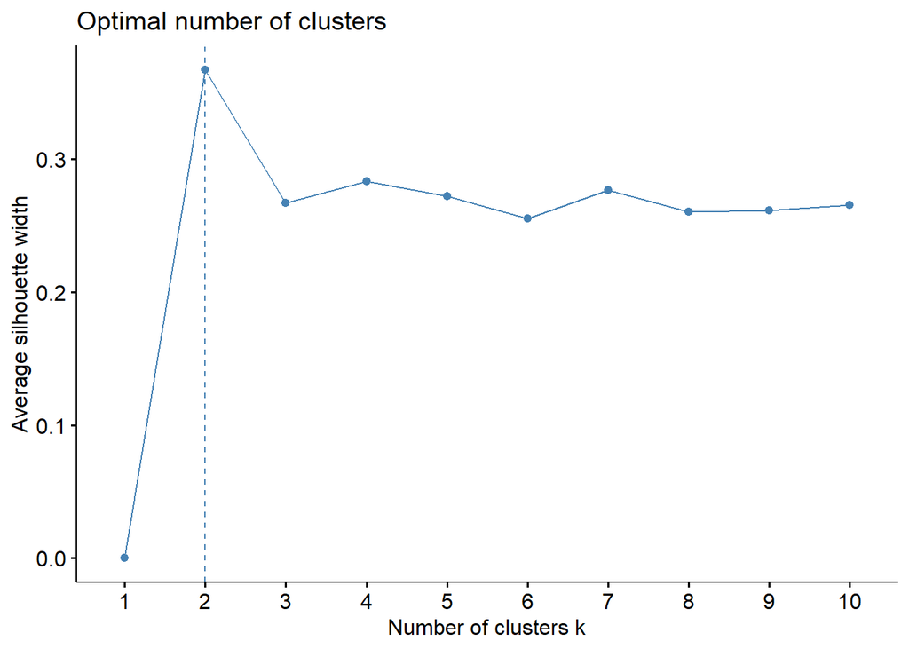

```r
fviz_nbclust(scaled_data, FUN = kmeans, method = "silhouette")
```

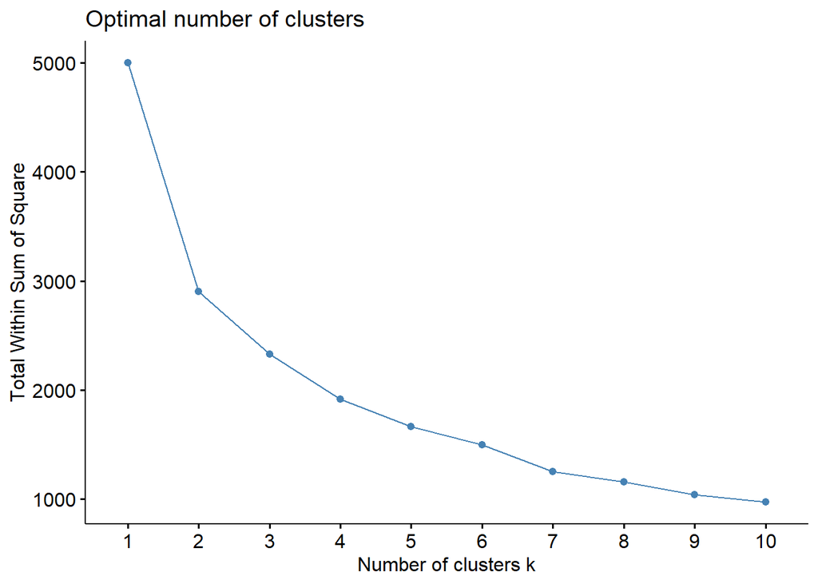

```r
fviz_nbclust(scaled_data, FUN = kmeans, method = "wss")
```

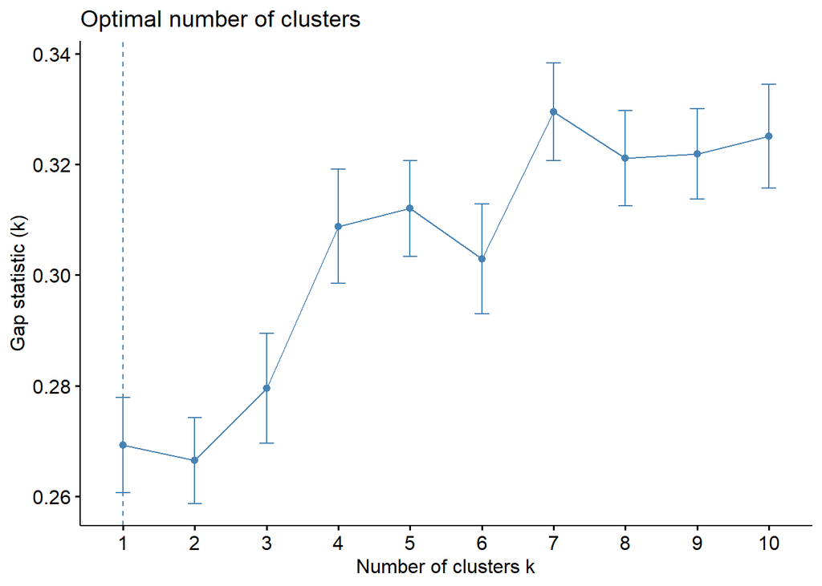

```r
fviz_nbclust(scaled_data, FUN = kmeans, method = "gap_stat")
```

```r
#Aseguramos la reproducibilidad, establecemos la semilla del generador de números aleatorios
seed_val <- 123
set.seed(seed_val)
# Número de clusters
k = 3
#Aplicamos k-means
sales_clust <- kmeans(scaled_data, centers = k)
#Ejemplos por grupos
sales_clust$size
```

```
## [1] 293 409 298
```

Los examinamos en detalle mediante representaciones gráficas.

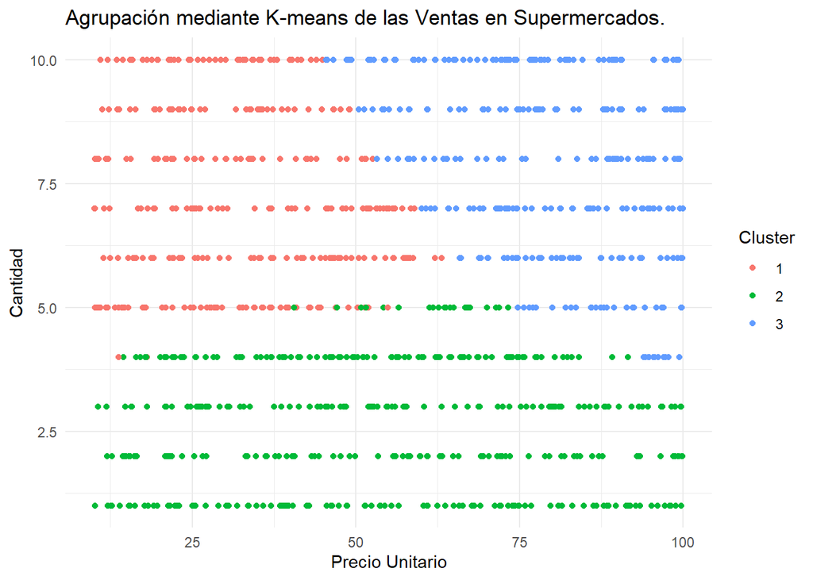

```r
#Incorporamos una columna adicional que indica el número del clúster al cual pertenece cada ejemplo.
sales_df$Cluster <- as.factor(sales_clust$cluster)

#Crear gráfica
ggplot(sales_df, aes(x = Unit.price, y = Quantity, color = Cluster)) +
  geom_point() +
  labs(title = "Agrupación mediante K-means de las Ventas en Supermercados.",
       x = "Precio Unitario", y = "Cantidad") +
  theme_minimal()
```

En la representación gráfica, se pueden identificar tres conjuntos diferenciados por colores distintos. Cada conjunto exhibe intervalos específicos para el precio unitario y la cantidad de productos vendidos.

El primer conjunto, destacado en rojo, se caracteriza por ser el más reducido pero con una mayor concentración. Este conjunto representa productos con precios unitarios bajos y cantidades significativas. Mayormente comprende productos esenciales de bajo costo, como arroz y frijoles, que son adquiridos en gran medida.

El segundo conjunto, identificado en verde, es más extenso que el primero y abarca un rango más amplio de precios unitarios. Esto sugiere una diversidad de artículos con precios unitarios tanto bajos como altos. Por ejemplo, productos como pollo, leche y papel higiénico podrían pertenecer a este conjunto.

## Clustering Jerárquico

Existen diversas estrategias para implementar el Clustering Jerárquico, y en este caso, optaremos por los métodos complete y single. La medición de la distancia entre los ejemplos se lleva a cabo mediante la función dist, la cual utiliza el método euclidean de forma predeterminada.

En el primer paso, procederemos a estimar el número de centros que debemos definir.

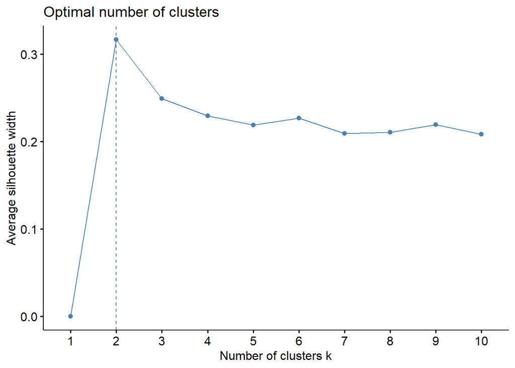

```r
fviz_nbclust(scaled_data, FUN = hcut, method = "silhouette")
```

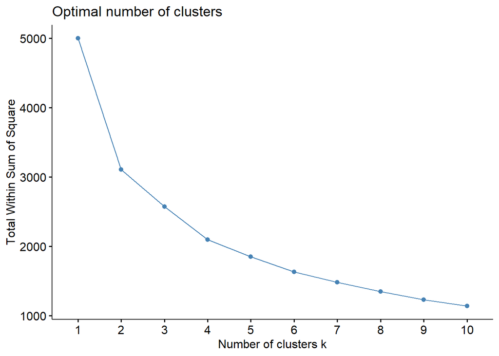

```r
fviz_nbclust(scaled_data, FUN = hcut, method = "wss")
```

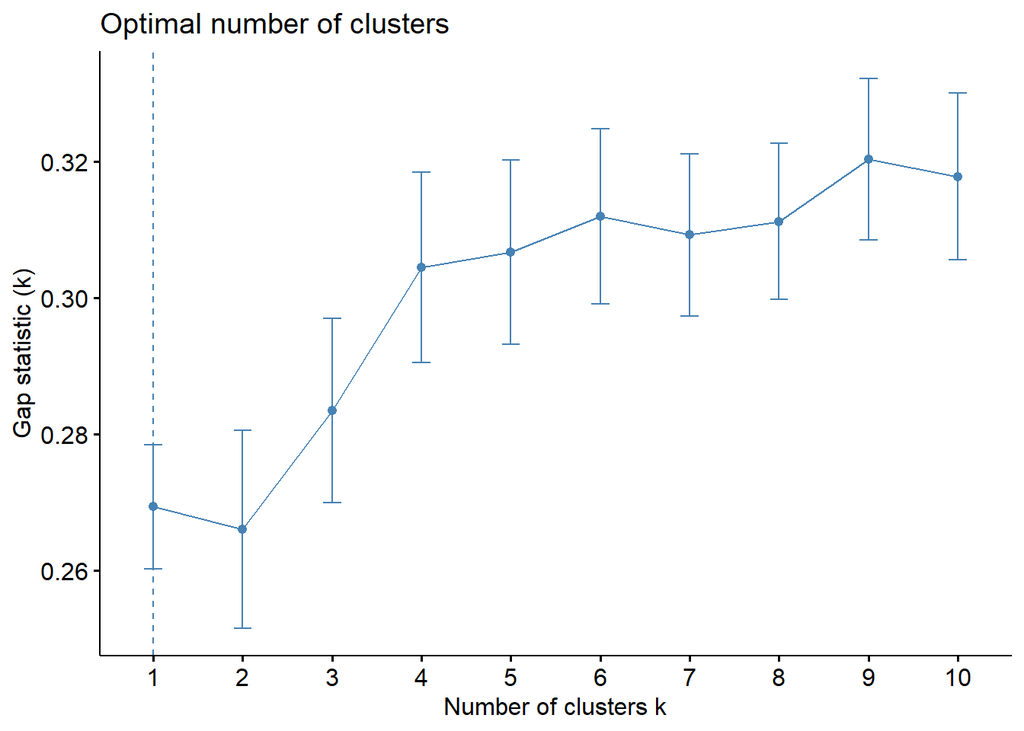

```r
fviz_nbclust(scaled_data, FUN = hcut, method = "gap_stat")
```

Atendiendo a las sugerencias proporcionadas por los métodos, procedemos a implementar ambos algoritmo jerárquicos para un valor específico de k, en este caso, k = 2.

### Clustering Jerárquico: Complete

El dendrograma posibilita la conexión entre los grupos a los cuales pertenecen los ejemplos. En otras palabras, las agrupaciones configuran un árbol en el cual cada rama que se origina representa un clúster.

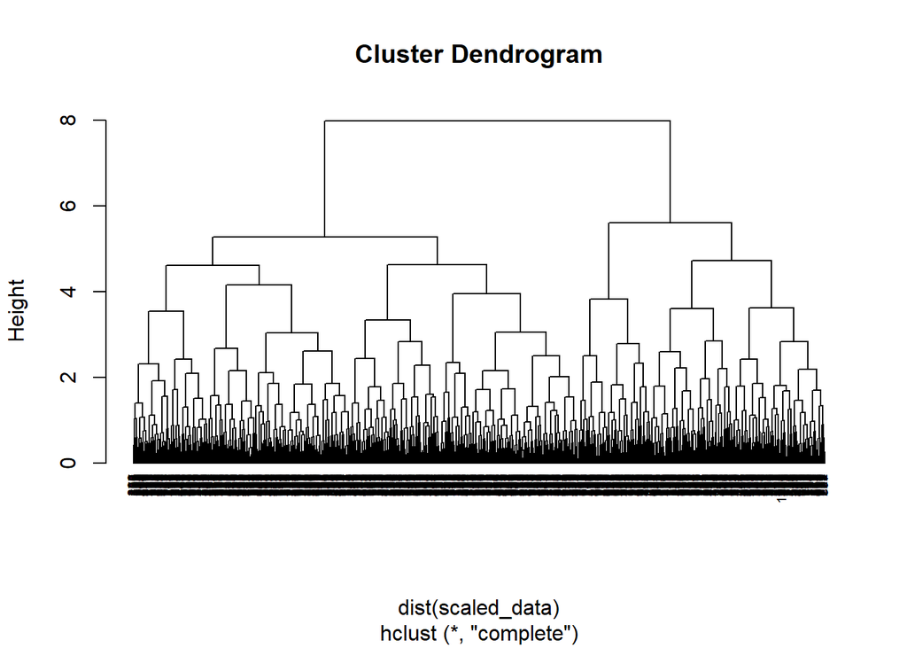

```r
hier_complete <- hclust(dist(scaled_data), method= 'complete')

plot(hier_complete, cex = 0.6, hang = -1)
```

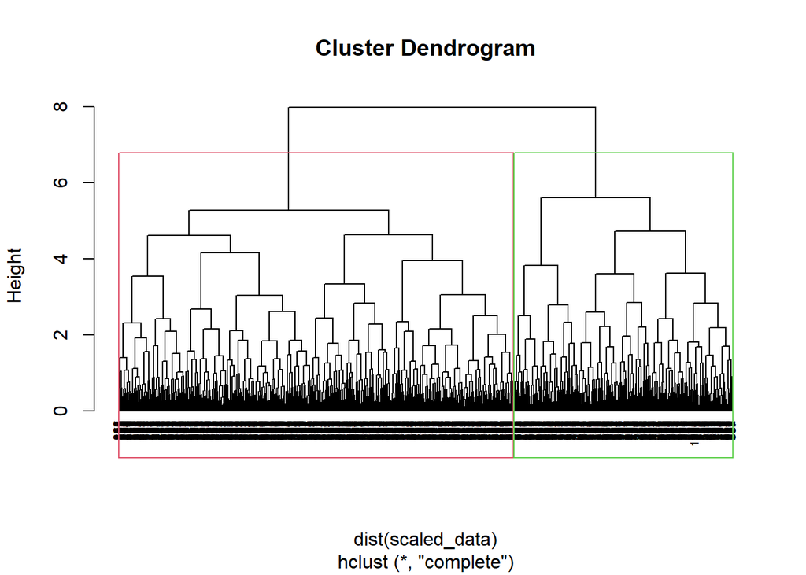

```r
plot(hier_complete, cex = 0.6, hang = -1)
rect.hclust(hier_complete, k = 2, border = 2:3)
```

Las conclusiones extraídas muestran similitudes con los resultados previamente obtenidos.

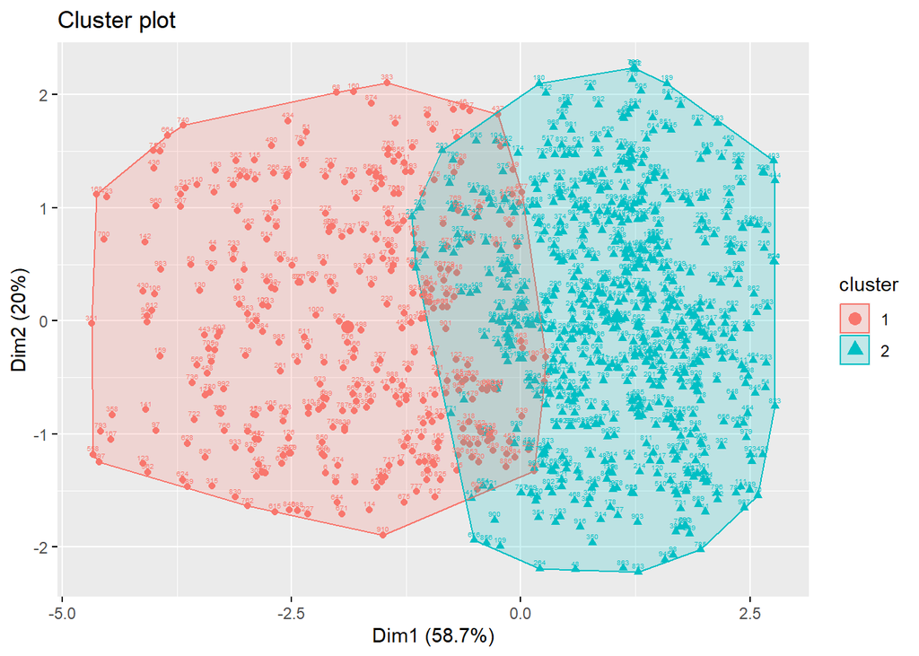

```r
s_clusters <- cutree(hier_complete, k = 2)
fviz_cluster(list(data = as.matrix(scaled_data), cluster = s_clusters), labels = 4)
```

## Clustering Jerárquico: Single

De manera similar al caso anterior, el dendrograma resultante al aplicar el clustering jerárquico nos facilita la conexión entre los grupos a los que pertenecen los ejemplos.

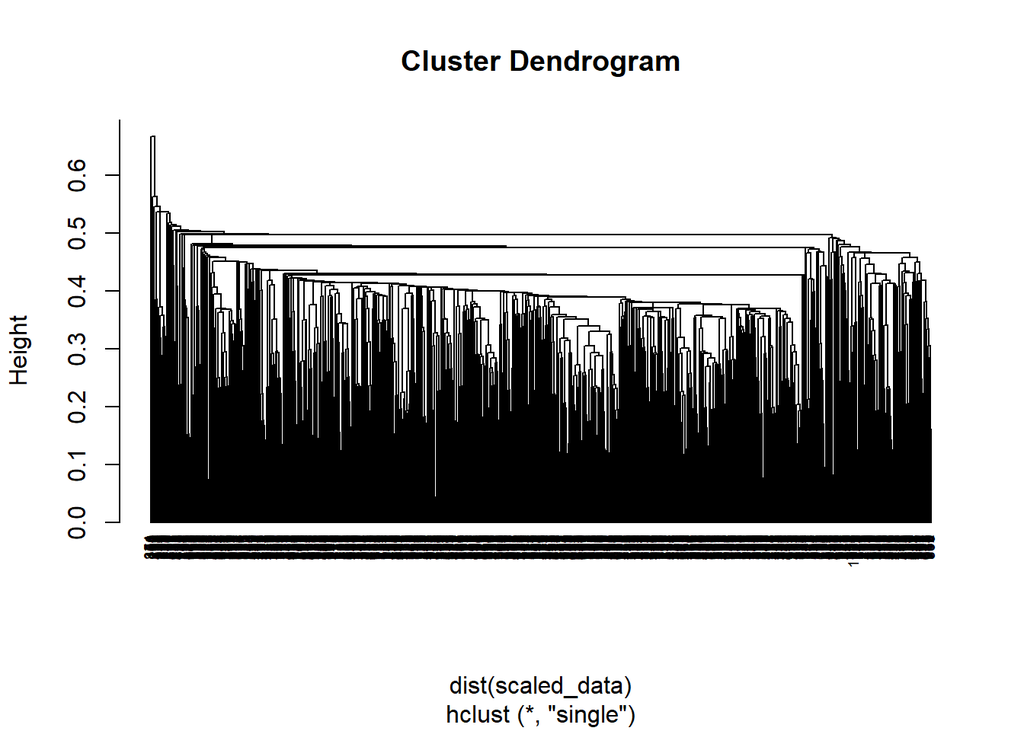

```r
hier_single <- hclust(dist(scaled_data), method= 'single')

plot(hier_single, cex = 0.6, hang = -1)
```

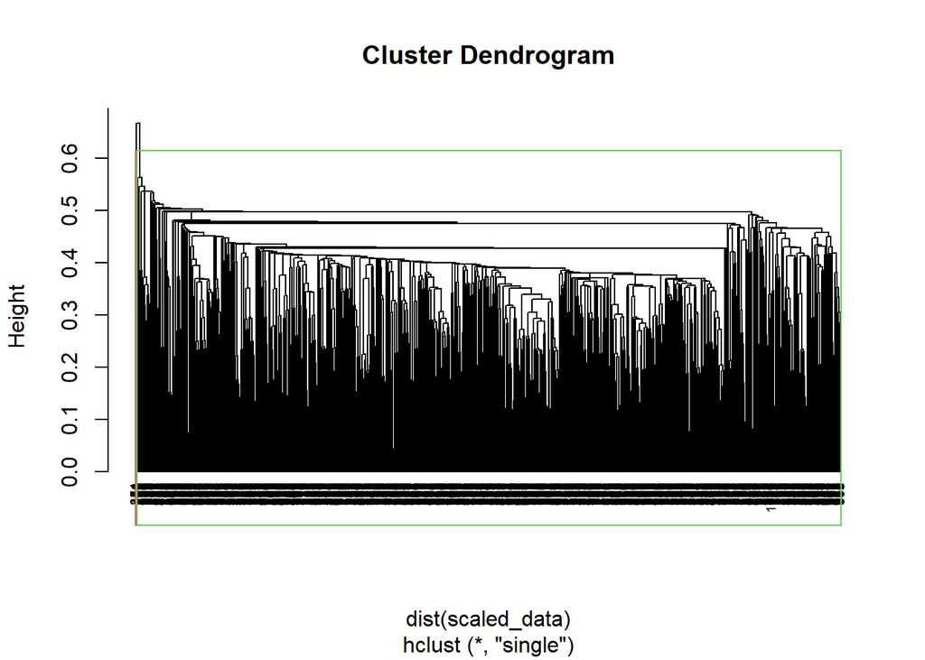

```r
plot(hier_single, cex = 0.6, hang = -1)
rect.hclust(hier_single, k = 2, border = 2:3)
```

Los resultados obtenidos muestran diferencias con respecto a los modelos aplicados anteriormente.

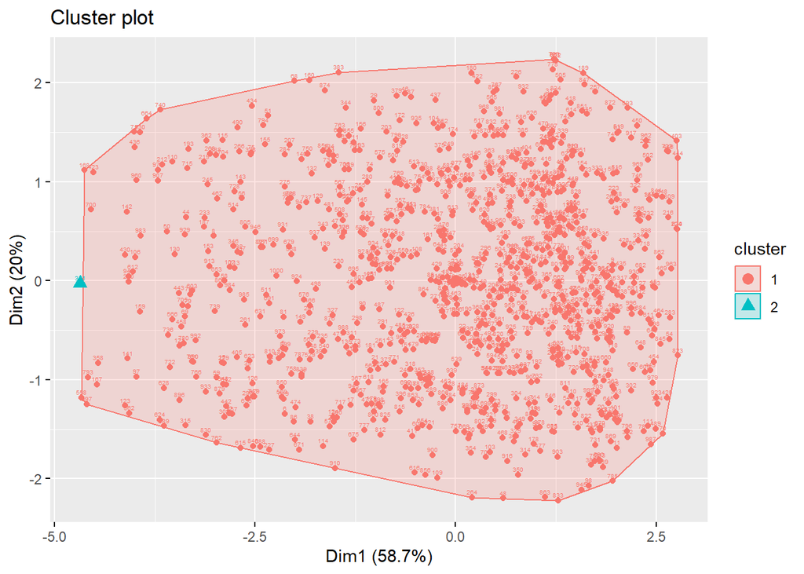

```r
sample_clusters <- cutree(hier_single, k = 2)
fviz_cluster(list(data = as.matrix(scaled_data), cluster = sample_clusters), labels = 4)
```

## Evaluación de los modelos

```r
comparison <- clValid(
                  obj = scaled_data,
                  nClust = 2:4,
                  clMethods = c("hierarchical", "kmeans"),
                  validation = c("stability", "internal"),
                  maxitems=nrow(scaled_data)
                  )
print(summary(comparison))
```

```
##
## Clustering Methods:
##  hierarchical kmeans
##
## Cluster sizes:
##  2 3 4
##
## Validation Measures:
##                                   2        3        4
##
## hierarchical APN             0.1945   0.3474   0.3679
##              AD              2.5578   2.3661   2.1906
##              ADM             0.8853   0.9356   0.9847
##              FOM             0.8115   0.8109   0.7200
##              Connectivity   85.0278 120.6004 164.3532
##              Dunn            0.0537   0.0618   0.0652
##              Silhouette      0.3228   0.2286   0.2233
## kmeans       APN             0.0566   0.2622   0.4152
##              AD              2.2925   2.1865   2.1395
##              ADM             0.1703   0.6993   1.0190
##              FOM             0.7678   0.7582   0.7458
##              Connectivity   83.6714 149.4948 212.3325
##              Dunn            0.0226   0.0296   0.0163
##              Silhouette      0.3671   0.2834   0.2527
##
## Optimal Scores:
##
##              Score   Method       Clusters
## APN           0.0566 kmeans       2
## AD            2.1395 kmeans       4
## ADM           0.1703 kmeans       2
## FOM           0.7200 hierarchical 4
## Connectivity 83.6714 kmeans       2
## Dunn          0.0652 hierarchical 4
## Silhouette    0.3671 kmeans       2
##
## NULL
```

## Referencias

https://rpubs.com/Joaquin_AR/310338